# 1-BasicMap

## Basic Map

We are going to make a basic map, but, this not a basic procedure. We have this file to expain things and a single R script (1-BasicMap.R).

## We Need Packages

Packages extend what basic R can do. For plotting a map we need several pacakges. Here are the ones we need for this example.

```r
library(tidyverse)
library(maps)
library(mapdata)
library(ggrepel)
```

The library command loads packages. Do you have these installed?

How can they be installed? Either within RStudio’s GUI or with install.packages command. We can talk about what these are.

## Getting our worldmap

We can get a basic outline of the world with the map_data command. Here is what that looks like.

```r
world<-map_data("world")
head(world)
```

```
##        long      lat group order region subregion
## 1 -69.89912 12.45200     1     1  Aruba      <NA>
## 2 -69.89571 12.42300     1     2  Aruba      <NA>
## 3 -69.94219 12.43853     1     3  Aruba      <NA>
## 4 -70.00415 12.50049     1     4  Aruba      <NA>
## 5 -70.06612 12.54697     1     5  Aruba      <NA>
## 6 -70.05088 12.59707     1     6  Aruba      <NA>
```

This style of data is easily plotted with ggplot. We can use the geom_polygon command and supply the x and y axes. The group tells geom_polygon what points to combine togethere. In the example here, every single “Aruba” point is in group 1.

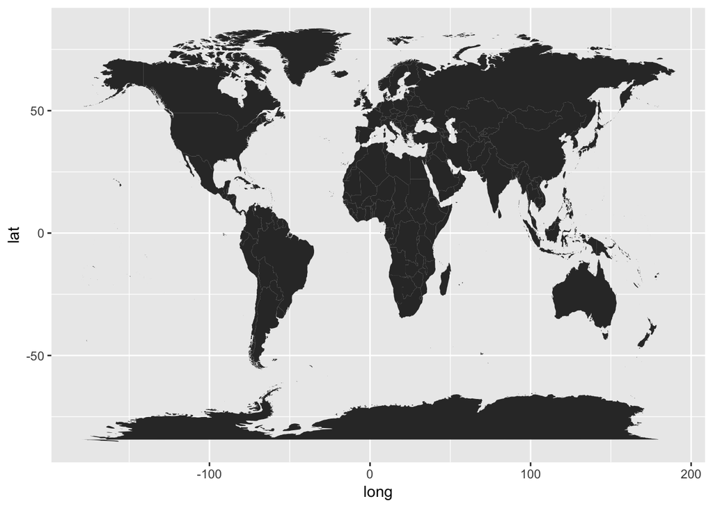

```r
ggplot(world)+geom_polygon(aes(x=long, y=lat, group=group))
```

If we were only interested in a particular country we can select that in a couple of ways. Check if these are the same.

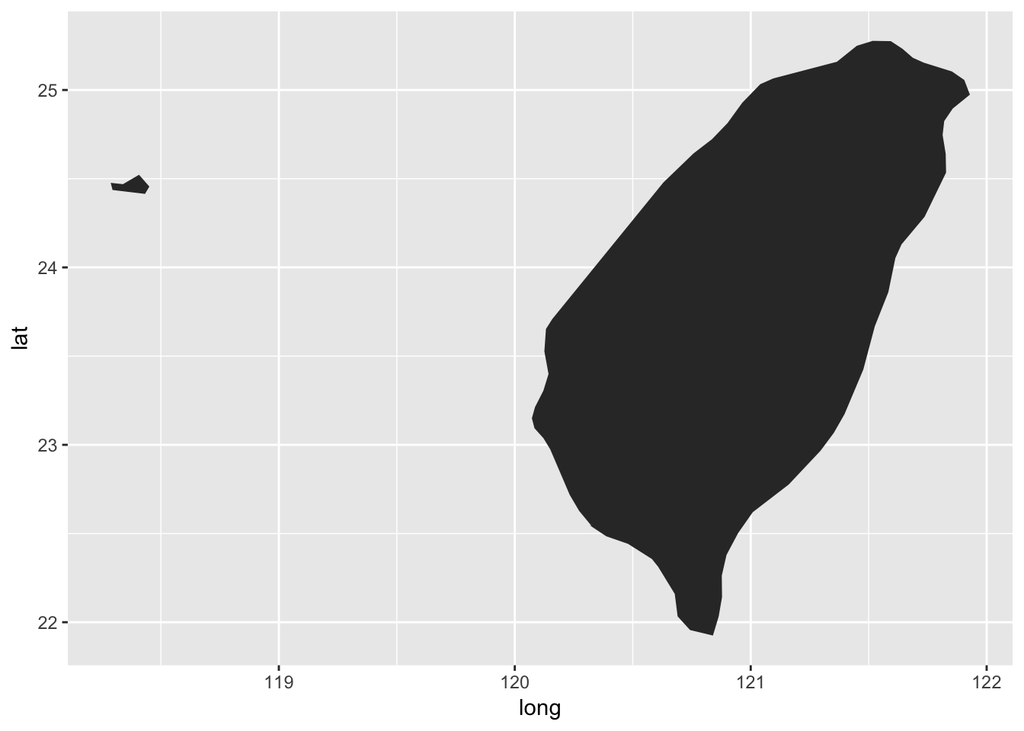

```r
taiwan1<-subset(world, region %in% c("Taiwan"))
taiwan2<-world %>% filter(region=="Taiwan")

ggplot(taiwan1)+geom_polygon(aes(x=long, y=lat, group=group))
```

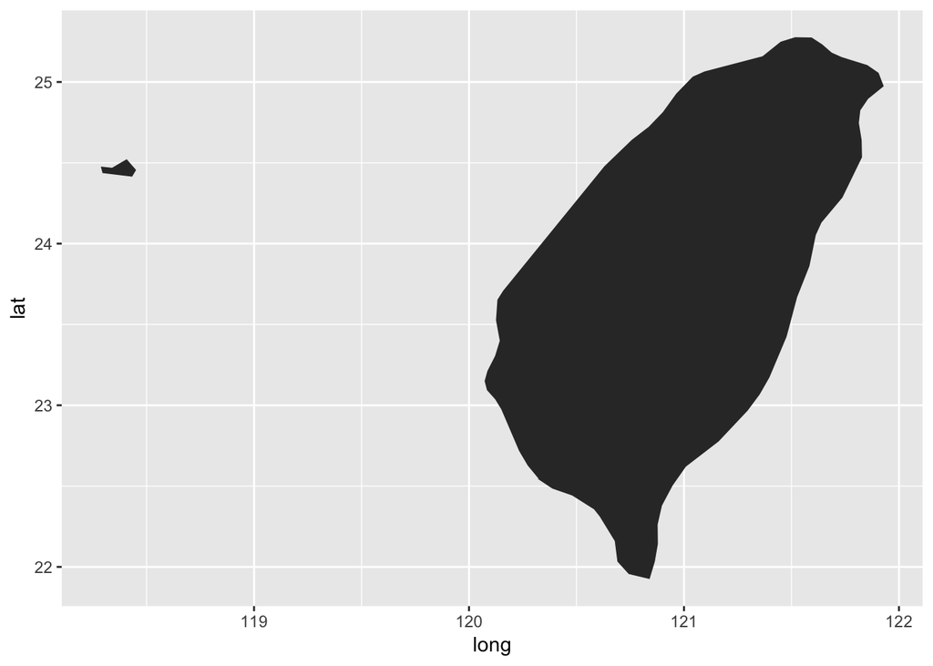

```r
ggplot(taiwan2)+geom_polygon(aes(x=long, y=lat, group=group))
```

## Making Things Pretty

We can make some alterations for aesthetics with the following commands and at the same time save this for later. There are many options that you can use to alter how things look in ggplot, and we could spend forever on that.

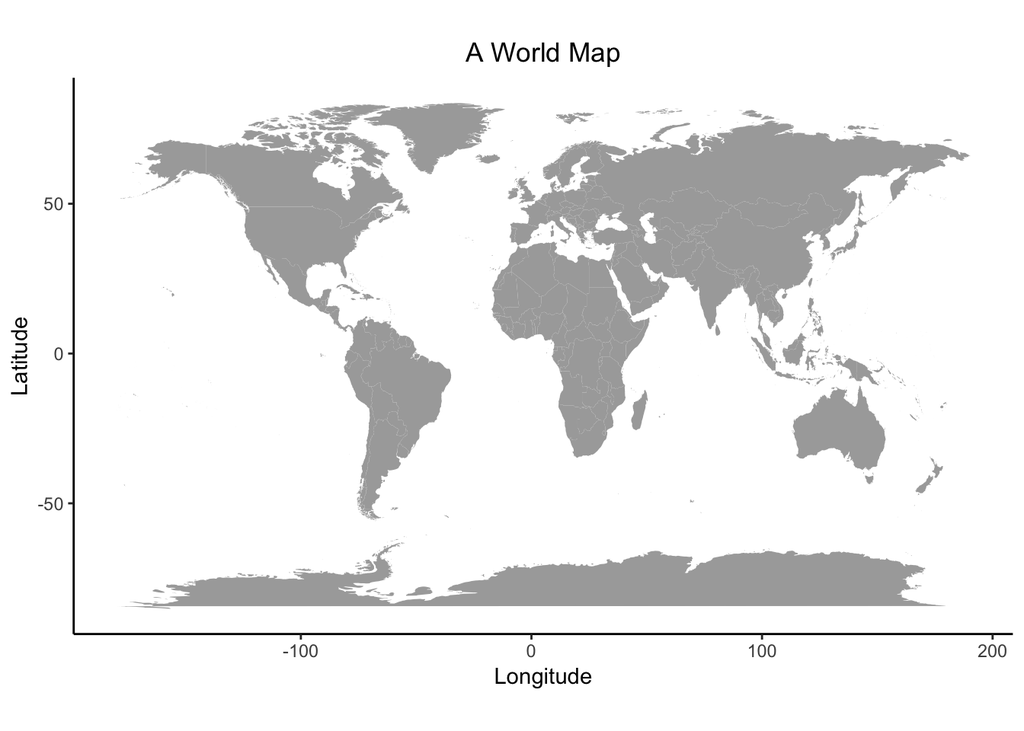

```r
map<-ggplot(world)+
  geom_polygon(aes(x=long, y=lat, group=group), fill="darkgrey")+
  coord_fixed(ratio=1.3)+
  ggtitle("A World Map")+
  xlab("Longitude")+
  ylab("Latitude")+
  theme_classic()+
  theme(plot.title = element_text(hjust = 0.5))

map
```

## Point Data

A common thing to do is plot point data. I made a text file of Taiwanese cities, coordinates, and population size. Something like this can easily be read into R and plotted with ggplot.

- There are many ways to read a file
- Make sure you are pointing to it

```r
data<-read.csv(file = "cities.txt", sep="\t")

#This is what it looks like
typeof(data)
```

```
## [1] "list"
```

```r
data
```

```
##         City Latitude Longitude Population
## 1  Kaohsiung 22.63333  120.2667    1402914
## 2 New Taipei 25.01111  121.4458    3974911
## 3   Taichung 24.15000  120.6667    2759887
## 4     Tainan 22.98333  120.1833    1885499
## 5     Taipei 25.06667  121.5167    2696316
## 6    Taoyuan 24.99128  121.3143    2136702
## 7     Chiayi 23.48000  120.4497     269890
## 8    Hsinchu 24.81667  120.9833     436220
## 9    Keelung 25.13333  121.7333     372019
```

We can again use ggplot to plot these data

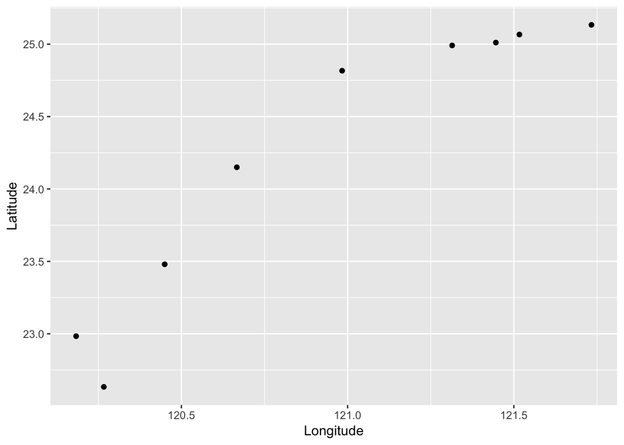

```r
ggplot()+geom_point(data=data, aes(x=Longitude, y=Latitude))
```

I would make this a bit different.

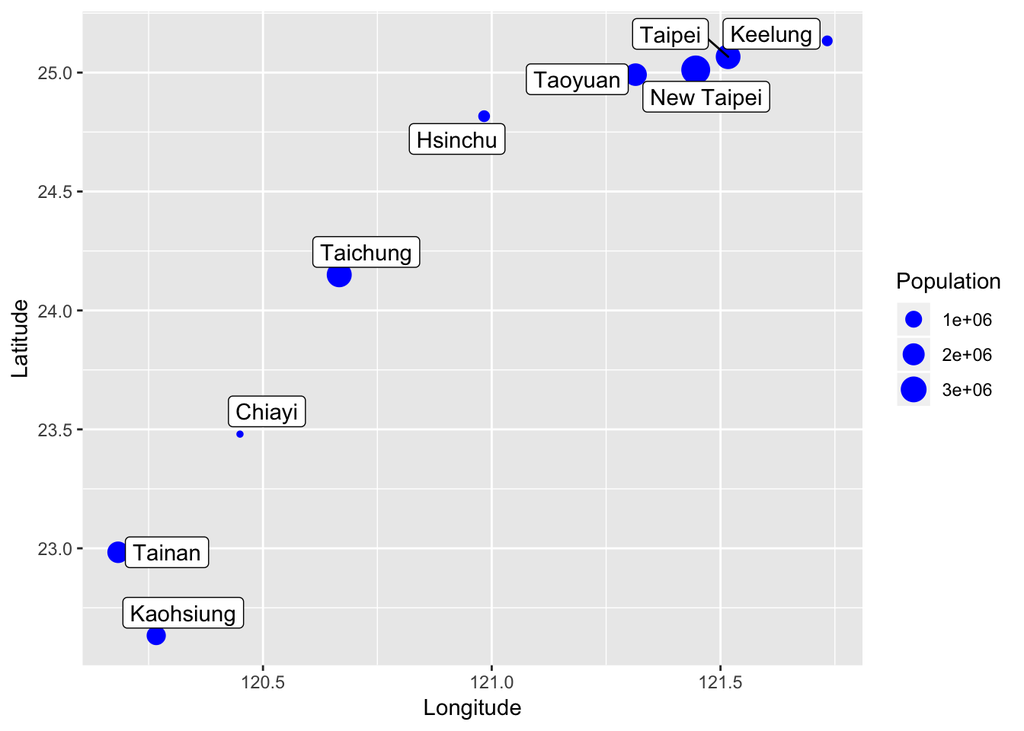

```r
ggplot()+geom_point(data=data, aes(x=Longitude, y=Latitude, size=Population), color="blue")+
  geom_label_repel(data=data, aes(x=Longitude, y=Latitude, label=City))
```

## Include These on a Map

We saved “map” earlier as a variable.

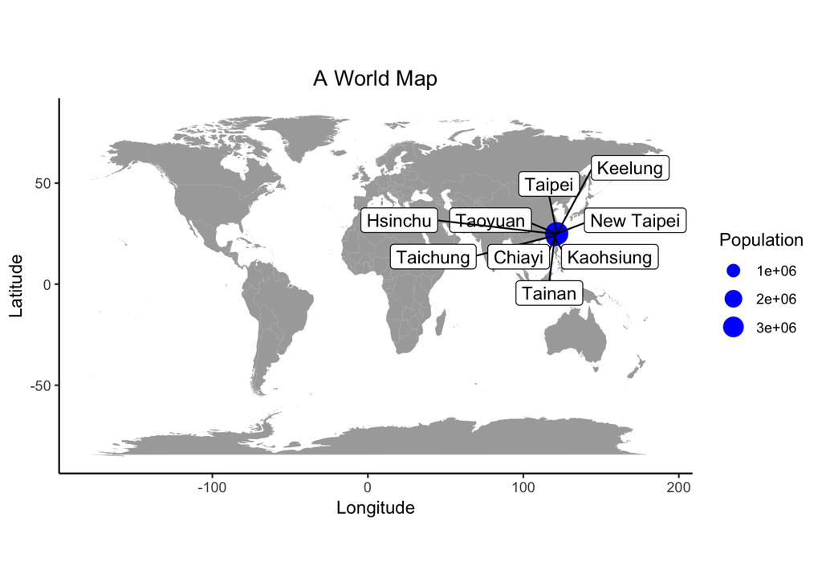

```r
map+geom_point(data=data, aes(x=Longitude, y=Latitude, size=Population), color="blue")+
  geom_label_repel(data=data, aes(x=Longitude, y=Latitude, label=City))
```

That plot wasn’t very helpful! We can zoom with coord_cartesian.

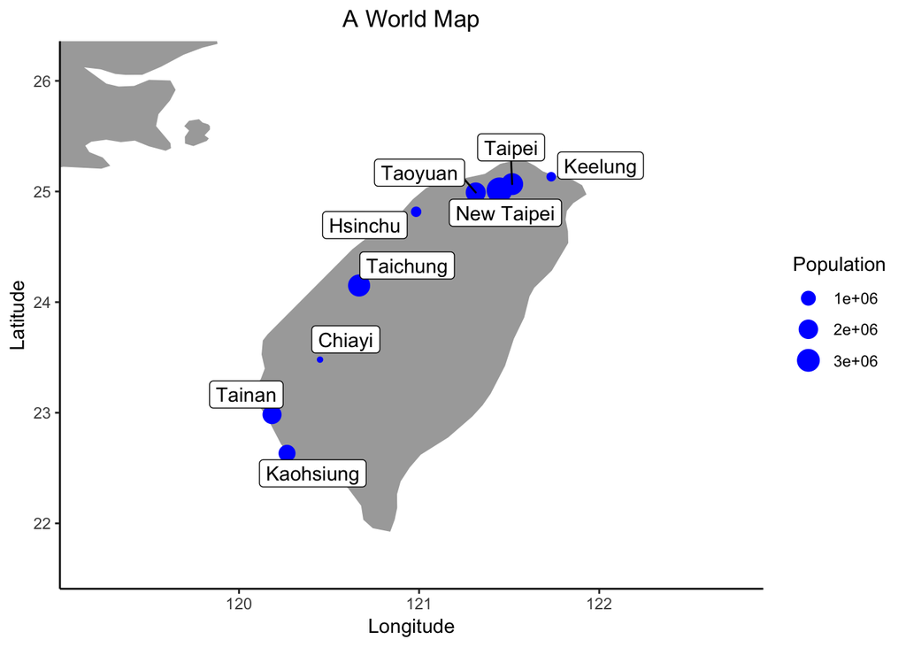

```r
map+geom_point(data=data, aes(x=Longitude, y=Latitude, size=Population), color="blue")+
  geom_label_repel(data=data, aes(x=Longitude, y=Latitude, label=City))+
  coord_cartesian(xlim=c(min(data$Longitude)-1, max(data$Longitude)+1),
                  ylim=c(min(data$Latitude)-1, max(data$Latitude)+1))
```